# What does provincial level GDP tell us about Iranian voting habits?

Cyrus Mohammadian

The recent parliamentary elections in Iran were a big win for the reformist camp. They not only managed to secure a (slim) majority in the Iranian Majles, they were also successful in adding significant numbers of reformist sympathizers to Iran’s Guardian Council -the organizational body tasked with selecting the next Supreme Leader to succeed Ayatollah Khamenei. A cursory examination of the results suggest that reformists performed particularly well in urban districts throughout the country and in Tehran in particular. One particular narrative that has emerged is that the upper class in Iran tend to vote reformist, while the working class poor gravitate towards the principalist camp.[^1] I bring this narrative under closer scrutiny using publicaly available data on the recent presidential and legislative elections.

Before getting into the data, I’ll provide some background on the mechanics of Iranian elections and the current political climate in the country. Then I’ll go through the workflow of my analysis, which begins with scraping data from the web, cleaning it, graphing it, and then plotting a few correlations that examine the effect of provincial level economic well being on Iranian voting habits.

## Presidential and Legislative Elections in Iran

Iran follows a two-round mixed-member district electoral voting system for its 290 member legislative body, which means 1) voters have the opporunity to elect one or more representatives per constituency and 2) leading candidates must secure at least 30% of the vote share in order to avoid a run-off against their nearest opponent. The numbers of seats is roughly allocated according to district population size. Districts size maxes out at 30 seats in Tehran, while the next largest is Tabriz with 6 and the the modal district size is 1. Of the 290 seats, 5 seats are reserved for officialy recognized religious minorities -one seat for Zoroastrians, one seat for Jews, two seats for Armenian Christians (North and South), and one seat for Assyrian and Chaldean Christians.

[figure not shown]

```r
library(dplyr)
library(plotrix)
library(ggplot2)

election<-function (seats, result, formula,
 colours = sample(rainbow(length(counts)))) {

 result <- model.frame(formula, result)
 counts <- result[, 2]
 stopifnot(sum(counts) == nrow(seats))
 seats$party <- factor(rep(result[, 1], counts))
 seats$colour <- colours[as.numeric(seats$party)]
 seats
}

colour<-c("lightgreen","green","darkgreen","yellow","purple","darkgrey")
party<-c("Tehran","Tabriz","Isfahan", "Mashad","Minorities","Rest")
members<-c(30,6,5,5,5,239)
data<-data.frame(colour, party, members)
data<-mutate_if(data, is.factor, as.character)
majles = seats(290, 10)
data.e = election(majles, data, party ~ members)

blank = theme(axis.line=element_blank(),
              axis.text.x=element_blank(),
              axis.text.y=element_blank(),
              axis.ticks=element_blank(),
              axis.title.x=element_blank(),
              axis.title.y=element_blank(),
              panel.background=element_blank(),
              panel.border=element_blank(),
              panel.grid.major=element_blank(),
              panel.grid.minor=element_blank(),
              plot.background=element_blank(),
              legend.title=element_blank())

ggplot(data.e, aes(x=x,y=y,col=party)) +
  geom_point(size=6) + coord_fixed() + blank +
  scale_color_manual(breaks = c("Rest","Tehran","Tabriz","Isfahan","Mashad","Minorities"),labels=c("Rest","Minorities","Isfahan", "Mashad","Tabriz","Tehran"),
                     values=c("red","green","yellow","darkgrey","purple","blue")) +
  theme(legend.position="bottom") +
  annotate("text", x = 0.01, y = 0.15, size= 25, label = "290")
```

## A Word About Parties in Iran

Iran does not have parties in the traditional sense of ideologically and strategically coherent political groups. This is in part due to norms that developed in the tumultuous atmosphere in which the Islamic Republic emerged. At the time of the revolution in 1979, the political lanscape was a checkerboard of various opposition groups united only by their will to collapse the Shah’s regime. Once the monarchy fell a tentative alliance emerged between the Islamist and Nationalist camps, perhaps best exemplified by the working relationship between Ayatollah Khomeini and Abolhassan Bani Sadr. Just as relations between them soured (tension between the two culminated in Bani Sadr’s resignation of the presidency and escape to France), so too did the tentative alliance between Nationalist and Islamist factions. Ultimately, the latter would emerge as triumphet. The harsh break with the Nationalists over the hostage taking crisis (amongst other disagreements), coupled with Saddam’s attack on Iran, allowed the Islamist faction to consolidate its power at the ballot box. As a result, although minor ideological factions emerged in the Islamic Republic’s nascent Constitutive Assembly, nothing resembling strong rivalrous parties took root.

In addition to the political climate that was unfavorable to the emergence of a strong party system in Iran, Iran’s Supreme Leader, Ayatollah Khomeini, harbored some [distrust](http://www.bashgah.net/fa/content/show/50239) towards party systems, suggesting that foreign powers may use them as a means to divide and conquer. As result, norms against strong parties emerged. Tentative party lists and alliances are formed but they rarely maintain strategic coherence in a single election let alone consistency across multiple election cycles.

In the most recent legislative elections in 2016, the reformist camp were lagely represented by two allied “lists” (other minor moderate groups and independents allied with each list as well); The Pervasive Coalition of Reformists: The Second Step (ائتلاف فراگیر اصلاطلبان: گام دوم), otherwise known as the “list of hope” (لیست امید), lead by Mohammad Reza Aref and the Front for the National Voice (جبهه صدای ملت), led by Ali Motahari. The Principalist faction is represented by only one coalition this election cycle - the Principlists Grand Coalition (ائتلاف بزرگ اصولگرایان), led by Gholam Ali Haddad-Adel. In the most recent presidential elections in 2013, Rouhani ran as a reformer while he faced a slate of conservatives and conservative minded independents. In the next section, I introduce election and recent socioeconomic data on Iran.

## The Data

Data on the 2016 parliamentary elections are scraped from Wikipedia’s persian language entry for that subject matter, while the data on the 2013 presidential election and socioeconomic data are scraped from the [Iran Data Portal](http://irandataportal.syr.edu) website hosted at Syracuse University.

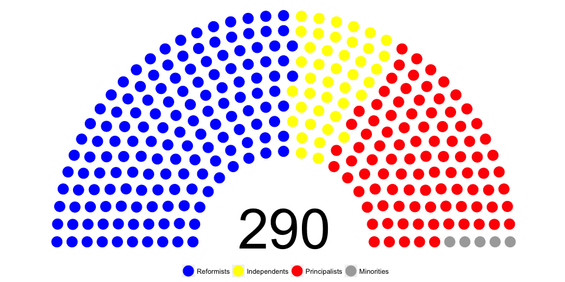

```r
library(dplyr)
library(plotrix)
library(ggplot2)

election<-function (seats, result, formula,
 colours = sample(rainbow(length(counts)))) {

 result <- model.frame(formula, result)
 counts <- result[, 2]
 stopifnot(sum(counts) == nrow(seats))
 seats$party <- factor(rep(result[, 1], counts))
 seats$colour <- colours[as.numeric(seats$party)]
 seats
}

set.seed(1)
colour<-c("lightgreen","green","darkgreen","darkgrey")
party<-c("Reformists","Independents","Principalist", "Minorities")
members<-c(150,41,94, 5)
data<-data.frame(colour, party, members)
data<-mutate_if(data, is.factor, as.character)
majles = seats(290, 10)
data.e = election(majles, data, party ~ members)


blank = theme(axis.line=element_blank(),
              axis.text.x=element_blank(),
              axis.text.y=element_blank(),
              axis.ticks=element_blank(),
              axis.title.x=element_blank(),
              axis.title.y=element_blank(),
              panel.background=element_blank(),
              panel.border=element_blank(),
              panel.grid.major=element_blank(),
              panel.grid.minor=element_blank(),
              plot.background=element_blank(),
              legend.title=element_blank())

ggplot(data.e, aes(x=x,y=y,col=party)) +
  geom_point(size=6) + coord_fixed() + blank +
  scale_color_manual(breaks = c("Reformists","Independents","Principalist","Minorities"), labels=c("Reformists","Independents","Principalists","Minorities"),
                     values=c("yellow","darkgrey","red","blue")) +
  theme(legend.position="bottom") +
  annotate("text", x = 0.01, y = 0.15, size= 25, label = "290")
```

```r
#Load dependencies
library(rvest)
library(dplyr)
library(pipeR)
library(stringr)
library(translateR)
library(XML)
library(gdata)
library(reshape2)
library(gdata)
library(reshape2)
library(dplyr)
library(readr)
library(rgdal)
library(maptools)
library(ggplot2)
library(plotly)

#Pass Plotly username and password to environment
Sys.setenv("plotly_username"="cmohamma")
Sys.setenv("plotly_api_key"="udr1tkmg4f")

#Scrape table from Wikipedia
url <- "https://fa.wikipedia.org/wiki/فهرست_نمایندگان_دوره_دهم_مجلس_شورای_اسلامی"

ir.election2016 <- url %>%
  read_html() %>%
  html_nodes(xpath='//*[@id="mw-content-text"]/table') %>%
  html_table(fill = TRUE)
ir.election2016<-ir.election2016[[2]]

#Translate column names into English
colnames(ir.election2016)<-c("name", "district","province","coalition","nothing")
ir.election2016$nothing<-NULL

#Get rid of numbers of special characters using regex
ir.election2016$coalition<-str_replace_all(ir.election2016$coalition, "[\\]۱۲۳۴۴۵۶۷۸۹۰\\[]", "")
ir.election2016$coalition[ir.election2016$coalition==""]<-NA

#Translate all data but politician names into English
ir.election2016[ir.election2016=="لرستان"]<-"Lorestan"
ir.election2016$coalition.eng <- translate(content.vec = ir.election2016$coalition,
                                           microsoft.client.id = "thelakerswon",
                                           microsoft.client.secret =
                                             "GYIGd9nDwphSSTeGc+VVeDwn1RRGi86o1p4No1effYs=",
                                           source.lang =  "fa" ,
                                           target.lang =  "en" )
ir.election2016$province.eng <- translate(content.vec = ir.election2016$province,
                                          microsoft.client.id = "thelakerswon",
                                          microsoft.client.secret =
                                            "GYIGd9nDwphSSTeGc+VVeDwn1RRGi86o1p4No1effYs=",
                                          source.lang =  "fa" ,
                                          target.lang =  "en" )

#Clean province names and remove data for ethnic minorities
ir.election2016$province.eng[ir.election2016$province.eng=="Isfahan, Iran"]<-"Isfahan"
ir.election2016$province.eng[ir.election2016$province.eng=="Khuzestan province"]<-"Khuzestan"
ir.election2016$province.eng[ir.election2016$province.eng=="Semnan, Iran"]<-"Semnan"
ir.election2016$province.eng[ir.election2016$province.eng=="Gillan"]<-"Gilan"
ir.election2016$province.eng[ir.election2016$province.eng=="Bushehr port"]<-"Bushehr"
ir.election2016$province.eng[ir.election2016$province.eng=="Fars."]<-"Fars"
ir.election2016$province.eng[ir.election2016$province.eng=="Central"]<-"Markazi"
ir.election2016$province.eng[ir.election2016$province.eng=="Chaharmahal and Bakhtiari"]<-"Chahar Mahal and Bakhtiari"
ir.election2016$province.eng[ir.election2016$province.eng=="Ardabil"]<-"Ardebil"
ir.election2016$province.eng[ir.election2016$province.eng=="West Azarbaijan"]<-"West Azerbaijan"
ir.election2016$province.eng[ir.election2016$province.eng=="Kohgiluyeh and Boyer-Ahmad"]<-"Kohgiluyeh and Buyer Ahmad"

ir.election2016$coalition.eng[ir.election2016$coalition.eng=="NA"]<-NA
ir.election2016 <- ir.election2016[-grep("Iran", ir.election2016$province.eng, perl=TRUE), ]

#Convert coalitions to ideology
ir.election2016$ideology<-ir.election2016$coalition.eng
ir.election2016$ideology[ir.election2016$ideology=="NA"]<-NA
ir.election2016$ideology[ir.election2016$ideology=="Independent"]<-"independent"
ir.election2016$ideology[ir.election2016$ideology=="The great coalition of conservatives _ the second stage of"]<-"reformist"
ir.election2016$ideology[ir.election2016$ideology=="The reformist Coalition inclusive"]<-"reformist"
ir.election2016$ideology[ir.election2016$ideology=="Moderation and development party"]<-"reformist"
ir.election2016$ideology[ir.election2016$ideology=="The voice of the nation"]<-"reformist"
ir.election2016$ideology[ir.election2016$ideology=="Probe"]<-"principlist"
ir.election2016$ideology[ir.election2016$ideology=="The great coalition of conservatives"]<-"principlist"
ir.election2016$ideology[ir.election2016$ideology=="Revolutionary Trustees"]<-"principlist"
ir.election2016$ideology[ir.election2016$ideology=="The great coalition of conservatives اصلاحطلبانائتلاف inclusive"]<-"principlist"
ir.election2016$ideology[ir.election2016$ideology=="The reformist Coalition encompassing the great coalition of conservatives"]<-"principlist"

#Inspect independents and convert to appropriate ideology based on wikipedia bios in persian
ir.election2016$id<-1:284
ir.election2016$ideology<-ifelse(ir.election2016$id== "7",
                                 "principlist",
                                 ir.election2016$ideology)
ir.election2016$ideology<-ifelse(ir.election2016$id== "9",
                                 "reformist",
                                 ir.election2016$ideology)
ir.election2016$ideology<-ifelse(ir.election2016$id== "11",
                                 "reformist",
                                 ir.election2016$ideology)
ir.election2016$ideology<-ifelse(ir.election2016$id== "24",
                                 "reformist",
                                 ir.election2016$ideology)
ir.election2016$ideology<-ifelse(ir.election2016$id== "29",
                                 "reformist",
                                 ir.election2016$ideology)
ir.election2016$ideology<-ifelse(ir.election2016$id== "30",
                                 "principlist",
                                 ir.election2016$ideology)
ir.election2016$ideology<-ifelse(ir.election2016$id== "37",
                                 "principlist",
                                 ir.election2016$ideology)
ir.election2016$ideology<-ifelse(ir.election2016$id== "38",
                                 "principlist",
                                 ir.election2016$ideology)
ir.election2016$ideology<-ifelse(ir.election2016$id== "54",
                                 "principlist",
                                 ir.election2016$ideology)
ir.election2016$ideology<-ifelse(ir.election2016$id== "59",
                                 "principlist",
                                 ir.election2016$ideology)
ir.election2016$ideology<-ifelse(ir.election2016$id== "143",
                                 "principlist",
                                 ir.election2016$ideology)
ir.election2016$ideology<-ifelse(ir.election2016$id== "148",
                                 "principlist",
                                 ir.election2016$ideology)
ir.election2016$ideology<-ifelse(ir.election2016$id== "151",
                                 "principlist",
                                 ir.election2016$ideology)
ir.election2016$ideology<-ifelse(ir.election2016$id== "163",
                                 "principlist",
                                 ir.election2016$ideology)
ir.election2016$ideology<-ifelse(ir.election2016$id== "173",
                                 "reformist",
                                 ir.election2016$ideology)
ir.election2016$ideology<-ifelse(ir.election2016$id== "178",
                                 "reformist",
                                 ir.election2016$ideology)
ir.election2016$ideology<-ifelse(ir.election2016$id== "214",
                                 "principlist",
                                 ir.election2016$ideology)
ir.election2016$ideology<-ifelse(ir.election2016$id== "217",
                                 "principlist",
                                 ir.election2016$ideology)
ir.election2016$ideology<-ifelse(ir.election2016$id== "221",
                                 "principlist",
                                 ir.election2016$ideology)
ir.election2016$ideology<-ifelse(ir.election2016$id== "241",
                                 "principlist",
                                 ir.election2016$ideology)
ir.election2016$ideology<-ifelse(ir.election2016$id== "242",
                                 "principlist",
                                 ir.election2016$ideology)
ir.election2016$ideology<-ifelse(ir.election2016$id== "258",
                                 "reformist",
                                 ir.election2016$ideology)
ir.election2016$ideology<-ifelse(ir.election2016$id== "268",
                                 "reformist",
                                 ir.election2016$ideology)
ir.election2016$ideology<-ifelse(ir.election2016$id== "57",
                                 "principlist",
                                 ir.election2016$ideology)
ir.election2016$ideology<-ifelse(ir.election2016$id== "58",
                                 "principlist",
                                 ir.election2016$ideology)
ir.election2016$ideology<-ifelse(ir.election2016$id== "115",
                                 "reformist",
                                 ir.election2016$ideology)
ir.election2016$ideology<-ifelse(ir.election2016$id== "127",
                                 "principlist",
                                 ir.election2016$ideology)
ir.election2016$ideology[is.na(ir.election2016$ideology)]<-"independent"
```

```r
#Split data between reformist, principlist, and independents
reformist.df<-ir.election2016 %>%
  subset(ideology=="reformist") %>%
  group_by(province.eng) %>%
  summarize(reformist=n())
reformist.df<-as.data.frame(reformist.df)
principlist.df<-ir.election2016 %>%
  subset(ideology=="principlist") %>%
  group_by(province.eng) %>%
  summarize(principlist=n())
principlist.df<-as.data.frame(principlist.df)
independent.df<-ir.election2016 %>%
  subset(ideology=="independent") %>%
  group_by(province.eng) %>%
  summarize(independent=n())
independent.df<-as.data.frame(independent.df)

#Merge the split dataframes together
ir.election2016.sum<-merge(reformist.df, principlist.df, by="province.eng", all=TRUE)
ir.election2016.sum<-merge(ir.election2016.sum, independent.df, by="province.eng",all=TRUE)
ir.election2016.sum[is.na(ir.election2016.sum)]<-0

#Construct two-ideology vote share and independent vote share for each district
ir.election2016.sum$reform_rat<-ir.election2016.sum$reformist/(ir.election2016.sum$reformist+ir.election2016.sum$principlist+ir.election2016.sum$independent)
ir.election2016.sum$princ_rat<-ir.election2016.sum$principlist/(ir.election2016.sum$reformist+ir.election2016.sum$principlist+ir.election2016.sum$independent)
ir.election2016.sum$indep_rat<-ir.election2016.sum$independent/(ir.election2016.sum$reformist+ir.election2016.sum$principlist+ir.election2016.sum$independent)

#Rename province variable
ir.election2016.sum<-rename(ir.election2016.sum, province=province.eng)

##Presidency 2013
#Scrape table Iran Data Portal
url <- "http://irandataportal.syr.edu/election-data"
ir.pres2013 <- url %>%
  read_html() %>%
  html_nodes(xpath='//*[@id="content"]/div[16]/table') %>%
  html_table(fill = TRUE)
ir.pres2013<-ir.pres2013[[1]]
colnames(ir.pres2013)<-c("province","Rouhani","Velayati","Jalili","Ghalibaf","Rezai","Gharazi")
ir.pres2013<-ir.pres2013[-1,]

#Get rid of unnecessary rows
ir.pres2013<-ir.pres2013 %>%
  subset(province!="Votes Per Candidate") %>%
  subset(province!="Total Votes")

#remove odd characters and convert data to numeric
mystery_char = rawToChar(as.raw(c(0xc2, 0xa0)))
to_replace = sprintf('[,%s]', mystery_char)
clean_numbers = function (x) as.numeric(str_replace_all(x, to_replace, ''))
ir.pres2013 = ir.pres2013 %>% mutate_each(funs(clean_numbers), -province)
ir.pres2013$total<-sum(ir.pres2013[,2:7])
ir.pres2013$total<-rowSums(ir.pres2013[,2:7])
ir.pres2013$rouhani_rat<-ir.pres2013$Rouhani/ir.pres2013$total

#Align province names and merge
ir.pres2013$province[ir.pres2013$province=="Hamadan"]<-"Hamedan"
ir.pres2013$province[ir.pres2013$province=="Esfahan"]<-"Isfahan"
ir.pres2013$province[ir.pres2013$province=="North Khorasan "]<-"North Khorasan"
ir.pres2013$province[ir.pres2013$province=="South Khorasan "]<-"South Khorasan"
ir.pres2013$province[ir.pres2013$province=="Razavi Khorasan "]<-"Khorasan Razavi"
ir.pres2013$province[ir.pres2013$province=="Ardabil"]<-"Ardebil"
ir.pres2013$province[ir.pres2013$province=="Razavi Khorasan"]<-"Khorasan Razavi"
iran.elect<-merge(ir.pres2013,ir.election2016.sum, by="province")

###Socioeconomic data
##Population

url<-"http://irandataportal.syr.edu/wp-content/uploads/population-province-and-gender-census-2011.xlsx"
pop<-read.xls(url)
pop<-subset(pop, Province!="Total Country")
rownames(pop)<-1:31
pop$province<-pop$Province
pop$Province<-NULL
pop<-select(pop, province, Male, Female, Total)
pop$province<-as.character(pop$province)
pop$province[pop$province=="Hamadan"]<-"Hamedan"
pop$province[pop$province=="Esfahan"]<-"Isfahan"
pop$province[pop$province=="North Khorasan "]<-"North Khorasan"
pop$province[pop$province=="South Khorasan "]<-"South Khorasan"
pop$province[pop$province=="Razavi Khorasan "]<-"Khorasan Razavi"

iran.elect$province[iran.elect$province=="Ardebil"]<-"Ardabil"
iran.df<-merge(pop, iran.elect, by="province", all=TRUE)

##Gini
url<-"http://irandataportal.syr.edu/wp-content/uploads/GINI-by-Province-1.xlsx"
iran.df <- url %>%
  read.xls() %>%
  subset(X!="Iran (total)") %>%
  rename(province=X) %>%
  mutate(gini = rowSums(.[2:3])/2) %>%
  select(province, gini) %>%
  mutate(province = ifelse(province=="Hamadan", "Hamedan", as.character(province))) %>%
  mutate(province = ifelse(province=="Esfahan", "Isfahan", as.character(province))) %>%
  mutate(province = ifelse(province=="North Khorasan ", "North Khorasan", as.character(province))) %>%
  mutate(province = ifelse(province=="South Khorasan ", "South Khorasan", as.character(province))) %>%
  mutate(province = ifelse(province=="Razavi Khorasan ", "Khorasan Razavi", as.character(province))) %>%
  merge(iran.df, by="province", all=TRUE) %>%
  rename(population=Total, female_pop=Female, male_pop=Male)

##GDP/capita growth rate
url<-"http://irandataportal.syr.edu/wp-content/uploads/GDP-per-capita-without-oil-2000to2013-1.xlsx"
growth <- function(x)x/lag(x)-1 #GDP growth between 2012 and 2013
gdpgrow <- url %>%
  read.xls() %>%
  filter(Year..Gregorian.calendar.=="2012-2013" |
           Year..Gregorian.calendar.=="2013-2014") %>%
  select(3,5:35) %>%
  melt(id="Year..Iranian.calendar.") %>%
  rename(year=Year..Iranian.calendar.) %>%
  rename(province=variable) %>%
  rename(gdp.grow=value) %>%
  mutate(province = ifelse(province=="Hamadan", "Hamedan", as.character(province))) %>%
  mutate(province = ifelse(province=="Esfahan", "Isfahan", as.character(province))) %>%
  mutate(province = ifelse(province=="South.Khorasan.", "South Khorasan", as.character(province))) %>%
  mutate(province = ifelse(province=="North.Khorasan.", "North Khorasan", as.character(province))) %>%
  mutate(province = ifelse(province=="Razavi.Khorasan.", "Khorasan Razavi", as.character(province))) %>%
  group_by(province) %>%
  mutate_each(funs(growth), gdp.grow) %>% #GDP growth function from above
  filter(year==1392) %>%
  select(2,3)
gdpgrow$province<-str_replace_all(gdpgrow$province, "[.]"," ")
final<-merge(gdpgrow, iran.df, by="province", all=TRUE)

##GDP/capita from 2013
url<-"http://irandataportal.syr.edu/wp-content/uploads/GDP-per-capita-without-oil-2000to2013-1.xlsx"
gdpcap <- url %>%
  read.xls() %>%
  filter(Year..Gregorian.calendar.=="2013-2014") %>%
  select(3,5:35) %>%
  melt(id="Year..Iranian.calendar.") %>%
  rename(year=Year..Iranian.calendar.) %>%
  rename(province=variable) %>%
  rename(gdp.cap=value) %>%
  mutate(province = ifelse(province=="Hamadan", "Hamedan", as.character(province))) %>%
  mutate(province = ifelse(province=="Esfahan", "Isfahan", as.character(province))) %>%
  mutate(province = ifelse(province=="South.Khorasan.", "South Khorasan", as.character(province))) %>%
  mutate(province = ifelse(province=="North.Khorasan.", "North Khorasan", as.character(province))) %>%
  mutate(province = ifelse(province=="Razavi.Khorasan.", "Khorasan Razavi", as.character(province))) %>%
  select(2,3)
gdpcap$province<-str_replace_all(gdpcap$province, "[.]"," ")
final<-merge(gdpcap, final, by="province", all=TRUE)
```

```r
##Unemployment
url<-"http://irandataportal.syr.edu/wp-content/uploads/3.-economic-participation-and-unemployment-rates-for-populationa-aged-10-and-overa-by-ostan-province-1380-1384-2001-2005.xlsx"
unemp <- url %>%
  read.xls(fileEncoding="latin1") #must add this option to get it to import

#Convert factors to characters
unemp[] <- lapply(unemp, as.character)
unemp<-unemp[c(3,5:34),]
unemp$X<-as.character(unemp$X)
unemp[1,1]<-"province"
colnames(unemp)<-unemp[1,]
unemp<-unemp[-1,]
colnames(unemp)<-c("province","a","B","c","d","E","f","g","H","i","j","K","l","m","N","o")
unemp<-select(unemp,1,3, 6, 9, 12, 15)
pattern = "\\(2\\)"
clean_numbers = function (x) as.numeric(str_replace_all(x, pattern, ""))
unemp<-mutate_each(unemp, funs(clean_numbers), -province)
unemp$Z<-(rowSums(select(unemp,-1))) #mean unemployment between 2000-2005
unemp$unemp<-unemp$Z/5
unemp<-unemp[,c(1,8)]
b<-c("Alborz"," ") #add data for missing Alborz (wasn't it's own province, based on research 14.9 selected)
unemp<-rbind(unemp, b)
unemp[31,2]<-14.9
unemp$unemp<-as.numeric(unemp$unemp)
unemp<-arrange(unemp, province)
unemp.avg<-unemp$unemp
final<-cbind(final,unemp.avg)

###Create table for means of measurements
library(formattable)

SummaryTable <- data.frame(
  Variables=c("Reformist Vote Share 2016","Independent Vote Share 2016","Principalist Vote Share 2016","Rouhani Vote Share 2013","Unemployment Rate","Gini Index","GDP/capita"),
  Mean=c("51%","16%","34%","53%","12.04%","0.31","105993"),
  Minimum=c("0%","0%","0%","33%","1.42%","0.25","49962"),
  Maximum=c("100%","50%","100%","73%","21.04%","0.38","337586"),
  Tehran=c("94%","0%","6%","49%","12%","0.31","178774")
)

formattable(SummaryTable, list(
  Variables= formatter(
    "span",
    style=x ~ style(color="black",
                    font.weight="bold",
                    background.color = "#00ff00",
                    border.radius="4px",
                    display="block",
                    padding= "0 4px"),
    Tehran= formatter(
      "span",
      style= ~ style(font.weight="bold")
    )
  )
)
)
```

| Variables | Mean | Minimum | Maximum | Tehran |
| --- | --- | --- | --- | --- |
| Reformist Vote Share 2016 | 51% | 0% | 100% | 94% |
| Independent Vote Share 2016 | 16% | 0% | 50% | 0% |
| Principalist Vote Share 2016 | 34% | 0% | 100% | 6% |
| Rouhani Vote Share 2013 | 53% | 33% | 73% | 49% |
| Unemployment Rate | 12.04% | 1.42% | 21.04% | 12% |
| Gini Index | 0.31 | 0.25 | 0.38 | 0.31 |
| GDP/capita | 105993 | 49962 | 337586 | 178774 |

# Graph elections

Now that I have the data scraped, cleaned, and combined, I can easily create an interactive map displaying not only both elections data but also the socioeconomic data I scraped earlier as well.

Workflow:

- Create function to download shapefiles from online sources
- Download shapefile and clean data slot
- Create ggplot2 object (static map)
- Wrap plotly arround ggplot2 object and map (interactive map)

```r
###Maps
#Function to download and import shapefile
dlshape=function(shploc, shpfile) {
  temp=tempfile()
  download.file(shploc, temp)
  unzip(temp)
  shp.data <- sapply(".", function(f) {
    fp <- file.path(temp, f)
    return(readOGR(".",shpfile))
  })
}


iran.sp <- dlshape(shploc="http://biogeo.ucdavis.edu/data/gadm2.8/shp/IRN_adm_shp.zip","IRN_adm1")[[1]]
```

```
FALSE OGR data source with driver: ESRI Shapefile
FALSE Source: ".", layer: "IRN_adm1"
FALSE with 31 features
FALSE It has 12 fields
```

```r
#Align spelling of provinces
iran.sp@data<-rename(iran.sp@data, province=NAME_1)
iran.sp@data$province<-as.character(iran.sp@data$province)
iran.sp@data$province[iran.sp@data$province=="Hamadan"]<-"Hamedan"
iran.sp@data$province[iran.sp@data$province=="Esfahan"]<-"Isfahan"
iran.sp@data$province[iran.sp@data$province=="Razavi Khorasan"]<-"Khorasan Razavi"
iran.sp@data$province[iran.sp@data$province=="North Khorasan "]<-"North Khorasan"
iran.sp@data$province[iran.sp@data$province=="South Khorasan "]<-"South Khorasan"
iran.sp@data$province[iran.sp@data$province=="Chahar Mahall and Bakhtiari"]<-"Chahar Mahal and Bakhtiari"
iran.sp@data$province[iran.sp@data$province=="Kordestan"]<-"Kurdistan"
iran.sp@data$province[iran.sp@data$province=="Chahar Mahall and Bakhtiari"]<-"Chahar Mahal and Bakhtiari"
iran.sp@data$province[iran.sp@data$province=="West Azarbaijan"]<-"West Azerbaijan"
iran.sp@data$province[iran.sp@data$province=="East Azarbaijan"]<-"East Azerbaijan"
iran.sp@data$province[iran.sp@data$province=="Ardebil"]<-"Ardabil"

#Apparenltly the shapefile's names do not match up with the coordinate locations -i.e. they're jumbled up
#So first create a copy of the province column
iran.sp@data$province2<-iran.sp@data$province
iran.sp@data$province2[iran.sp@data$province=="Fars"]<-"Isfahan"
iran.sp@data$province2[iran.sp@data$province=="Gilan"]<-"Fars"
iran.sp@data$province2[iran.sp@data$province=="Markazi"]<-"Mazandaran"
iran.sp@data$province2[iran.sp@data$province=="Isfahan"]<-"Ilam"
iran.sp@data$province2[iran.sp@data$province=="Lorestan"]<-"Markazi"
iran.sp@data$province2[iran.sp@data$province=="Hormozgan"]<-"Hamedan"
iran.sp@data$province2[iran.sp@data$province=="Khuzestan"]<-"Kohgiluyeh and Buyer Ahmad"
iran.sp@data$province2[iran.sp@data$province=="Kohgiluyeh and Buyer Ahmad"]<-"Kurdistan"
iran.sp@data$province2[iran.sp@data$province=="Khorasan Razavi"]<-"Khuzestan"
iran.sp@data$province2[iran.sp@data$province=="Mazandaran"]<-"North Khorasan"
iran.sp@data$province2[iran.sp@data$province=="Hamedan"]<-"Golestan"
iran.sp@data$province2[iran.sp@data$province=="Golestan"]<-"Gilan"
iran.sp@data$province2[iran.sp@data$province=="Qom"]<-"Khorasan Razavi"
iran.sp@data$province2[iran.sp@data$province=="North Khorasan"]<-"Qazvin"
iran.sp@data$province2[iran.sp@data$province=="Kurdistan"]<-"Lorestan"
iran.sp@data$province2[iran.sp@data$province=="Ilam"]<-"Hormozgan"
iran.sp@data$province2[iran.sp@data$province=="Qazvin"]<-"Qom"
iran.sp@data$province.og<-iran.sp@data$province
iran.sp@data$province<-iran.sp@data$province2
iran.sp@data$province2<-NULL

iran.sp@data$ID_1a<-iran.sp@data$ID_1
iran.sp@data$ID_1a[iran.sp@data$ID_1=="7"]<-"6"
iran.sp@data$ID_1a[iran.sp@data$ID_1=="8"]<-"7"
iran.sp@data$ID_1a[iran.sp@data$ID_1=="19"]<-"20"
iran.sp@data$ID_1a[iran.sp@data$ID_1=="6"]<-"12"
iran.sp@data$ID_1a[iran.sp@data$ID_1=="18"]<-"19"
iran.sp@data$ID_1a[iran.sp@data$ID_1=="11"]<-"10"
iran.sp@data$ID_1a[iran.sp@data$ID_1=="15"]<-"16"
iran.sp@data$ID_1a[iran.sp@data$ID_1=="16"]<-"17"
iran.sp@data$ID_1a[iran.sp@data$ID_1=="24"]<-"15"
iran.sp@data$ID_1a[iran.sp@data$ID_1=="20"]<-"21"
iran.sp@data$ID_1a[iran.sp@data$ID_1=="10"]<-"9"
iran.sp@data$ID_1a[iran.sp@data$ID_1=="9"]<-"8"
iran.sp@data$ID_1a[iran.sp@data$ID_1=="23"]<-"24"
iran.sp@data$ID_1a[iran.sp@data$ID_1=="21"]<-"22"
iran.sp@data$ID_1a[iran.sp@data$ID_1=="17"]<-"18"
iran.sp@data$ID_1a[iran.sp@data$ID_1=="12"]<-"11"
iran.sp@data$ID_1a[iran.sp@data$ID_1=="22"]<-"23"
iran.sp@data$ID_1.og<-iran.sp@data$ID_1
iran.sp@data$ID_1<-iran.sp@data$ID_1a
iran.sp@data$ID_1a<-NULL

iran.sp@data<-merge(iran.sp@data, final, by="province",all=TRUE)
iran.sp@data$ID_1<-as.numeric(iran.sp@data$ID_1)
iran.sp@data<-arrange(iran.sp@data, -desc(ID_1))

##Render data into df format for mapping
iran_map <- fortify(iran.sp, region="ID_1")

data<-merge(iran_map, iran.sp, region="id", by.x = "id", by.y = "ID_1")

###Plotly
#Rename variables to appropriate styles for display
colnames(data)[34]<-"Rouhani Vote Share 2013"
colnames(data)[40]<-"Independent Vote Share 2016"
colnames(data)[39]<-"Principalist Vote Share 2016"
colnames(data)[8]<-"Province"
colnames(data)[21]<-"GDP/capita"
colnames(data)[23]<-"Gini Index"
colnames(data)[41]<-"Unemployment Rate"
colnames(data)[38]<-"Reformist Vote Share 2016"

#ggplot the map
p<-ggplot(data, aes(x = long, y = lat, fill = `Reformist Vote Share 2016`, group = group,
                    label=`Independent Vote Share 2016`,
                    label2=`Principalist Vote Share 2016`,
                    label3=`Rouhani Vote Share 2013`,
                    label4=`Unemployment Rate`,
                    label5=`Gini Index`,
                    label6=`GDP/capita`,
                    label7=Province)) +
  geom_polygon(color="black", size=0.2) +
  ggtitle("Reformist Vote Share 2016") +
  scale_fill_gradient(low = "lightgrey", high = "darkred", name='Vote Share') +xlab("")+ylab("") +
  theme(axis.text = element_blank(),
        axis.title = element_blank(),
        axis.ticks = element_blank()) +
  theme(panel.grid.major = element_blank(), panel.grid.minor = element_blank(),
        panel.background = element_blank(), axis.line = element_line(colour = "black")) +
  theme(panel.grid.major = element_blank(), panel.grid.minor = element_blank(),
        panel.background = element_blank(), axis.line = element_line(colour = "black"))

#Convert to plotly object
gg <- plotly_build(p)

#Get rid of hover-over edit toolbar
gg<-gg %>%
  config(displayModeBar = FALSE) %>%
  config(showLink = FALSE)

#Save to plotly account
plotly_POST(gg, filename = "iran.plotly.100")
```

[interactive chart not shown]

The map above shows the distribution of reformist vote share by province. The reformist enjoyed greatest support in Yazd, Qazvin, and Tehran, while principalist were most successful in South Khorasan, Markazi, and Kermanshah provinces. In terms of the presidential race, Sistan and Baluchestan, Kurdistan, and Yazd are where the reformist candidate Rouhani enjoyed his best success, while he fared the poorest in Chahar Mahal and Bakhtiar, Khuzestan, and Qom.

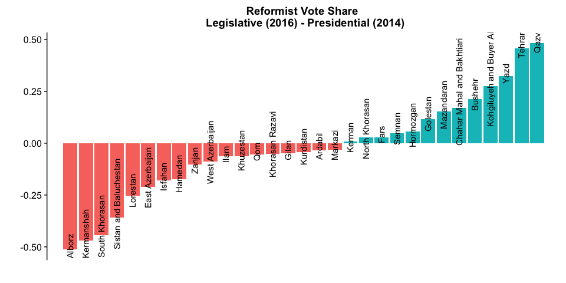

```r
library(cowplot)
data$f.diff<-data[,38]-data[,34]

plot.df<-unique(select(data, 8, 42))

plot.df$category<-ifelse(as.numeric(plot.df$f.diff)<0,0,1)
plot.df$category<-as.factor(plot.df$category)

plot.df$Province<-factor(plot.df$Province,
                         levels=plot.df[order(plot.df$f.diff), "Province"])

ggplot(data=plot.df, aes(x=Province, y=f.diff))+
  geom_bar(stat="identity", aes(fill=category)) +
  theme(axis.text.x = element_text(angle = 45, hjust = 2)) +
  theme(axis.text.x=element_text(colour="black"),
        legend.position="none") +
  xlab("") + ylab("") +
  geom_text(aes(label = Province, x = Province, y = f.diff),
            position = position_dodge(width = 3), angle = 90, hjust = 0.35) +
  theme(axis.text.x=element_blank(),
        axis.ticks.x=element_blank(),
        axis.line.x=element_blank()) +
  ggtitle("Reformist Vote Share \n Legislative (2016) - Presidential (2014)")
```

# Economic well-being and the reformist vote at the provincial level

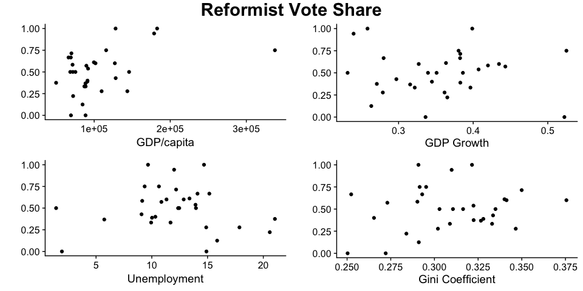

```r
data.df<-iran.sp@data

#Generate maps
library(gridExtra)
library(grid)

g1<-ggplot(data=data.df, aes(gdp.cap, reform_rat))+
  geom_point()+xlab("GDP/capita")+ylab("")
g2<-ggplot(data=data.df, aes(gdp.grow, reform_rat))+
  geom_point()+xlab("GDP Growth")+ylab("")
g3<-ggplot(data=data.df, aes(unemp.avg, reform_rat))+geom_point()+xlab("Unemployment")+ylab("")
g4<-ggplot(data=data.df, aes(gini, reform_rat))+
  geom_point() +xlab("Gini Coefficient")+ylab("")

grid.arrange(g1,g2,g3,g4, top = textGrob("Reformist Vote Share", gp=gpar(fontface="bold", fontsize=22)))
```

[^1]: See https://www.jacobinmag.com/2016/05/iran-elections-rouhani-reformists-nuclear-deal/ for an example.